# **Analyzing Literacy Rates Around the World**

By: Merliss George

# **Motivation**

In 1916, John Dewey, an American philosopher and educational reformer, said that "Education is not preparation for life; education is life itself". In 2021, the global literacy rate was approximately 0.85.

A 0.85 out of 1 seems pretty good, doesn't it? At first glance, yes, but there is more to the story. According to the World Population Review, in 2021, approximately 773 million people do not have basic literacy skills. Of those 773 million, over 250 million are children. While a 0.85 global literacy rate is great, 773 million people still not being able to read is something we, as a society need to work on.

Now, you may be wondering *why, why is literacy important?* Well, it is important for a variety of reasons. Higher literacy rates are associated with greater economic growth, lower unemployment rates, healthier populations, and less crime. Given all of these positive benefits associated with literacy, why is it not more heavily prioritized by society? Why isn't literacy used as often to "level the playing field" so to say? Knowing how to read is one of the best ways to create more equality. Learning how to read opens up more doors to a wide array of opportunities that may remain out of reach if one does not know how to read. This is why literacy, and more specifically globlal literacy, is so important. Being literate is enough to improve one's quality of life and help people not only survive but thrive as well.

In this tutorial, we will analyze data about the recorded literacy rates around the world between the years 2010 to 2018. This data was obtained from Kaggle (will elaborate more on this below). Analyzing data such as this could be helpful in potentially identifying regions/countries where primary school education or literacy programs are currently succeeding or, if it is not doing as well as was hoped, the data could assist in identifying potential solutions to remedy the issue.

Follow along with tutorial if you want to learn more about the Data Science Pipeline and want to attempt to make some new insights about global literacy!

**Step 1: Data Collection**

The first step of "The Data Science Pipeline" is Data Collection. For this tutorial, I will be using data that was obtained from Kaggle, which is an online community platform that allows data scientists to find, publish, and explore a wide variety of datasets. The dataset that I will be using to analyze the literacy rates around the world is called "Youth & Adult Literacy Rates".

This dataset from Kaggle was already in the format of a CSV so I did not have to do any website parsing, but sometimes it is necessary to do so. In situations where you might find yourself needing to scrape a website to extract the data you want, it is useful to make use of already existent Python libraries (if you are planning on using Python) such as Beautiful Soup. Beautiful Soup is specifically used for scraping data from HTML and XML files.

**Dataset Link:**

https://www.kaggle.com/datasets/thedevastator/youth-adult-literacy-rates-in-2019?resource=download

Now, it is necessary to read the data from the dataset (which is in the form of a CSV) into Python so we can work with it. We can do this by using the pandas library. More information on the pandas library and all of the other libraries being used in this tutorial can be found linked below under "Results"(bottom of the page).

```python
import pandas as pd
import numpy as np
import statistics as stat
import matplotlib.pyplot as plt
from sklearn.model_selection import train_test_split
from sklearn.linear_model import LinearRegression
from scipy.stats import shapiro
```

```python
data = pd.read_csv("/content/drive/MyDrive/Literacy rates (no pw2).csv")
```

```python
data.head(70)
```

|  | index | Region | Country | Year | Age | Gender | Literacy rate |
| --- | --- | --- | --- | --- | --- | --- | --- |
| 0 | 0 | Central and Southern Asia | Afghanistan | 2011 | 15+ | female | 0.176121 |
| 1 | 1 | Central and Southern Asia | Afghanistan | 2011 | 15+ | male | 0.454171 |
| 2 | 2 | Central and Southern Asia | Afghanistan | 2011 | 15+ | total | 0.317411 |
| 3 | 3 | Central and Southern Asia | Afghanistan | 2011 | 15-24 | female | 0.321132 |
| 4 | 4 | Central and Southern Asia | Afghanistan | 2011 | 15-24 | male | 0.618791 |
| ... | ... | ... | ... | ... | ... | ... | ... |
| 65 | 65 | Central and Southern Asia | Bangladesh | 2014 | 25-64 | female | 0.498879 |
| 66 | 66 | Central and Southern Asia | Bangladesh | 2014 | 25-64 | male | 0.587476 |
| 67 | 67 | Central and Southern Asia | Bangladesh | 2014 | 25-64 | total | 0.542513 |
| 68 | 68 | Central and Southern Asia | Bangladesh | 2014 | 65+ | female | 0.228539 |
| 69 | 69 | Central and Southern Asia | Bangladesh | 2014 | 65+ | male | 0.404505 |

70 rows × 7 columns

Above is a small sample of the dataset that we will use in this tutorial. As you can see, there are seven columns and they are labeled (from left to right) as index, Region, Country, Year, Age, Gender, and Literacy rate.

**Step 2: Data Wrangling**

From Kaggle, where the data was obtained from, the following information was given about each of the columns:

- Region = the region the data is from (String)
- Country = the country the data is from (String)
- Year = the year the data is from (Integer)
- Age = the age group the data is from (String)
- Gender = the gender the data is from (String)
- Literacy rate = the literacy rate for the given region, country, year, age, and gender (Float)

We can also use the shape variable to look at how many rows of data are present within the dataset. By doing so, we can see that there are 4955 rows within our dataset.

```python
data.shape
```

```
(4955, 7)
```

It can also be useful to print out the different categories for each column, especially if you know that multiple rows of a column will have the same value. Knowing what the different possible categories are for each column could be useful for when you are trying to select only specific data. One example of how to do this is shown below.

```python
print("Region Categories:", data['Region'].unique())
print()
print("Country Categories:", data['Country'].unique())
print()
print("Year Categories:", data['Year'].unique())
print()
print("Age Categories:", data['Age'].unique())
print()
print("Gender Categories:", data['Gender'].unique())
```

```
Region Categories: ['Central and Southern Asia' 'Eastern and South-Eastern Asia'
 'Europe and Northern America' 'Latin America and the Caribbean'
 'Northern Africa and Western Asia' 'Oceania' 'Sub-Saharan Africa']

Country Categories: ['Afghanistan' 'Bangladesh' 'Bhutan' 'India' 'Iran (Islamic Republic of)'
 'Kazakhstan' 'Kyrgyzstan' 'Maldives' 'Nepal' 'Pakistan' 'Sri Lanka'
 'Tajikistan' 'Turkmenistan' 'Uzbekistan' 'Brunei Darussalam' 'Cambodia'
 'China' 'China, Macao Special Administrative Region' 'Indonesia'
 "Lao People's Democratic Republic" 'Malaysia' 'Mongolia' 'Myanmar'
 'Philippines' 'Singapore' 'Thailand' 'Timor-Leste' 'Viet Nam' 'Albania'
 'Belarus' 'Bosnia and Herzegovina' 'Bulgaria' 'Croatia' 'Estonia'
 'Greece' 'Hungary' 'Italy' 'Latvia' 'Lithuania' 'Malta' 'Montenegro'
 'Portugal' 'Republic of Moldova' 'Romania' 'Russian Federation'
 'San Marino' 'Serbia' 'Slovenia' 'Spain'
 'The former Yugoslav Republic of Macedonia' 'Ukraine'
 'Antigua and Barbuda' 'Argentina' 'Aruba' 'Barbados'
 'Bolivia (Plurinational State of)' 'Brazil' 'Chile' 'Colombia'
 'Costa Rica' 'Cuba' 'Dominican Republic' 'Ecuador' 'El Salvador'
 'Grenada' 'Guadeloupe' 'Guatemala' 'Guyana' 'Haiti' 'Honduras' 'Jamaica'
 'Martinique' 'Mexico' 'Nicaragua' 'Panama' 'Paraguay' 'Peru'
 'Puerto Rico' 'Suriname' 'Trinidad and Tobago' 'Uruguay'
 'Venezuela (Bolivarian Republic of)' 'Algeria' 'Armenia' 'Azerbaijan'
 'Bahrain' 'Cyprus' 'Egypt' 'Georgia' 'Iraq' 'Jordan' 'Kuwait' 'Lebanon'
 'Morocco' 'Oman' 'Palestine' 'Qatar' 'Saudi Arabia' 'Sudan' 'Tunisia'
 'Turkey' 'Fiji' 'Marshall Islands' 'New Caledonia\xa0' 'Palau'
 'Papua New Guinea' 'Samoa' 'Tonga' 'Vanuatu' 'Angola' 'Benin' 'Botswana'
 'Burkina Faso' 'Burundi' 'Cabo Verde' 'Cameroon'
 'Central African Republic' 'Chad' 'Comoros' 'Congo' "Côte d'Ivoire"
 'Democratic Republic of the Congo' 'Equatorial Guinea' 'Eritrea'
 'Ethiopia' 'Gabon' 'Gambia' 'Ghana' 'Guinea' 'Guinea-Bissau' 'Kenya'
 'Lesotho' 'Liberia' 'Madagascar' 'Malawi' 'Mali' 'Mauritania' 'Mauritius'
 'Mozambique' 'Namibia' 'Niger' 'Nigeria' 'Rwanda' 'Sao Tome and Principe'
 'Senegal' 'Seychelles' 'Sierra Leone' 'South Africa' 'South Sudan'
 'Swaziland' 'Togo' 'Uganda' 'United Republic of Tanzania' 'Zambia'
 'Zimbabwe']

Year Categories: [2011 2018 2012 2013 2014 2015 2016 2017 2010]

Age Categories: ['15+' '15-24' '25-64' '65+']

Gender Categories: ['female' 'male' 'total']
```

**Step 3: Data Exploration**

By looking at the size of the dataset (4955 rows) and the number of different categories within the columns, it is pretty clear that it would be difficult to make any sort of meaninful insights by looking at all of the data as a whole. Instead, it would be better to look at small amounts of data and determine if there are any relationships/correlations to be found there that can help us make more insightful observations/analyses.

For example, if we wanted to look at female literacy rates in the Europe and North America region, we could create a plot which would allow us to visually analyze the statistic.

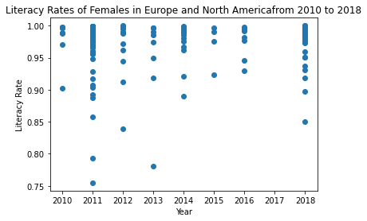

```python
df_females = data[data["Gender"] == "female"]

df_females_europe = df_females[df_females["Region"] ==
                              "Europe and Northern America"]


fig, ax = plt.subplots()

ax.scatter(df_females_europe["Year"], df_females_europe["Literacy rate"])
ax.set_xlabel("Year")
ax.set_ylabel("Literacy Rate")
ax.set_title("Literacy Rates of Females in Europe and North America" +
"from 2010 to 2018")
plt.show()
```

The scatter plot above depicts the literacy rates in females in countries that are part of the Europe and North America region between the years of 2010 and 2018.

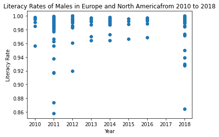

```python
df_males = data[data["Gender"] == "male"]

df_males_europe = df_males[df_males["Region"] ==
                              "Europe and Northern America"]


fig, ax = plt.subplots()

ax.scatter(df_males_europe["Year"], df_males_europe["Literacy rate"])
ax.set_xlabel("Year")
ax.set_ylabel("Literacy Rate")
ax.set_title("Literacy Rates of Males in Europe and North America" +
"from 2010 to 2018")
plt.show()
```

The scatter plot above depicts the literacy rates in males in countries that are part of the Europe and North America region between the years of 2010 and 2018.

From a preliminary glance at the two scatter plots above, the first depicting the literacy rates of females in the Europe and North America region from 2010 to 2018 and the second depicting the literacy rates of males in the Europe and North America region from 2010 to 2018, it appears that the points on the female graph are a bit more sporadic, especially pre-2016, when compared to the male graph. This seems to suggest that up until fairly recently, it was more likely for a female to be illiterate than for a man to be illiterate.

Now that we have examined the difference in literacy rates between genders in the Europe and North America regions, we could also look into what role age plays in literacy. Our dataset provides us with four different age classifications: (15+), (15-24), (25-64), and (65+). Let's look at how literacy rates differ between the different age groups in the Latin America and the Caribbean region.

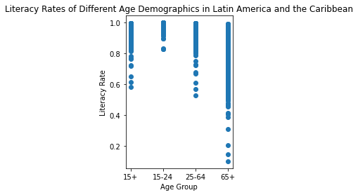

```python
df_latinAm_age = data[data["Region"] == "Latin America and the Caribbean"]


f = plt.figure()
ax = f.add_subplot(1,2,1)
ax.scatter(df_latinAm_age["Age"], df_latinAm_age["Literacy rate"])
ax.set_xlabel("Age Group")
ax.set_ylabel("Literacy Rate")
ax.set_title("Literacy Rates of Different Age Demographics in Latin America \
and the Caribbean")
plt.show()
```

The above scatter plot depicts the differences in literacy rates among different age demographics in the Latin America and the Caribbean region. Looking at the plot, you can see that the 65+ age demographic has the largest variance in literacy rates. An interesting point that the graph makes, however, is that 15-24 year olds boast the highest literacy rate while that of the 15+ and 25-64 demographics have very similar literacy distributions on the scatter plot.

Another example of data exploration that we could conduct is if we wanted to only look at the literacy rates of the different regions in the year 2010 compared to in 2018, we could create a scatter plot of the two different years.

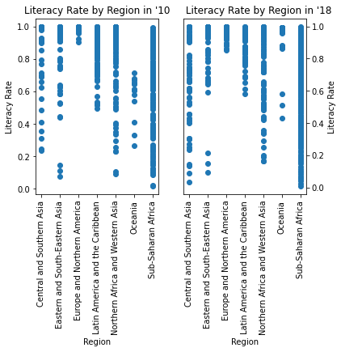

```python
df_2010 = data[data["Year"] == 2010]
df_2018 = data[data["Year"] == 2018]

f = plt.figure()
ax = f.add_subplot(1,2,1)
plt.scatter(df_2010["Region"], df_2010["Literacy rate"])
plt.xlabel("Region")
plt.xticks(rotation=90)
plt.ylabel("Literacy Rate")
plt.title("Literacy Rate by Region in '10")

ax = f.add_subplot(1,2,2)
ax.yaxis.tick_right()
ax.yaxis.set_label_position("right")
plt.scatter(df_2018["Region"], df_2018["Literacy rate"])
plt.xlabel("Region")
plt.xticks(rotation=90)
plt.ylabel("Literacy Rate", rotation=90)
plt.title("         Literacy Rate by Region in '18")

plt.show()
```

Looking at the above result, it is difficult to tell exactly what this graph is telling us about each region. To get a clearer picture about the overall literacy rates per region, we should compare the average literacy rates per region in the years 2010 and 2018.

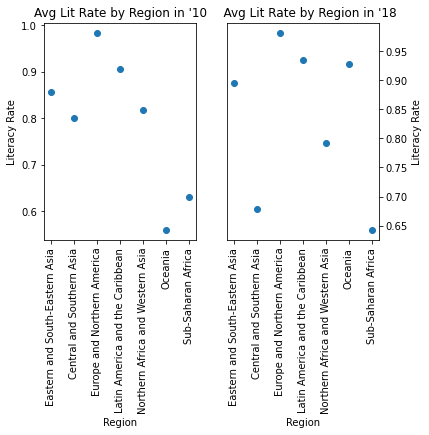

```python
# computes the average value of a list
def mean(lst):
  return sum(lst) / len(lst)

regions = ["Eastern and South-Eastern Asia",
           "Central and Southern Asia",
           "Europe and Northern America",
           "Latin America and the Caribbean",
           "Northern Africa and Western Asia",
           "Oceania", "Sub-Saharan Africa"]

df_eastAsia_10 = df_2010[df_2010["Region"] == "Eastern and South-Eastern Asia"]
df_centAsia_10 = df_2010[df_2010["Region"] == "Central and Southern Asia"]
df_europe_10 = df_2010[df_2010["Region"] == "Europe and Northern America"]
df_latinAm_10 = df_2010[df_2010["Region"] == "Latin America and the Caribbean"]
df_northAfrica_10 = df_2010[df_2010["Region"] == "Northern Africa and Western Asia"]
df_oceania_10 = df_2010[df_2010["Region"] == "Oceania"]
df_subAfrica_10 = df_2010[df_2010["Region"] == "Sub-Saharan Africa"]

arr_eastAsia_10 = mean(df_eastAsia_10["Literacy rate"].tolist())
arr_centAsia_10 = mean(df_centAsia_10["Literacy rate"].tolist())
arr_europe_10 = mean(df_europe_10["Literacy rate"].tolist())
arr_latinAm_10 = mean(df_latinAm_10["Literacy rate"].tolist())
arr_northAfrica_10 = mean(df_northAfrica_10["Literacy rate"].tolist())
arr_oceania_10 = mean(df_oceania_10["Literacy rate"].tolist())
arr_subAfrica_10 = mean(df_subAfrica_10["Literacy rate"].tolist())

avg_lit_rate_per_region_2010 = [arr_eastAsia_10, arr_centAsia_10, arr_europe_10,
                            arr_latinAm_10, arr_northAfrica_10, arr_oceania_10,
                            arr_subAfrica_10]



df_eastAsia_18 = df_2018[df_2018["Region"] == "Eastern and South-Eastern Asia"]
df_centAsia_18 = df_2018[df_2018["Region"] == "Central and Southern Asia"]
df_europe_18 = df_2018[df_2018["Region"] == "Europe and Northern America"]
df_latinAm_18 = df_2018[df_2018["Region"] == "Latin America and the Caribbean"]
df_northAfrica_18 = df_2018[df_2018["Region"] == "Northern Africa and Western Asia"]
df_oceania_18 =  df_2018[df_2018["Region"] == "Oceania"]
df_subAfrica_18 = df_2018[df_2018["Region"] == "Sub-Saharan Africa"]

arr_eastAsia_18 = mean(df_eastAsia_18["Literacy rate"].tolist())
arr_centAsia_18 = mean(df_centAsia_18["Literacy rate"].tolist())
arr_europe_18 = mean(df_europe_18["Literacy rate"].tolist())
arr_latinAm_18 = mean(df_latinAm_18["Literacy rate"].tolist())
arr_northAfrica_18 = mean(df_northAfrica_18["Literacy rate"].tolist())
arr_oceania_18 = mean(df_oceania_18["Literacy rate"].tolist())
arr_subAfrica_18 = mean(df_subAfrica_18["Literacy rate"].tolist())

avg_lit_rate_per_region_2018 = [arr_eastAsia_18, arr_centAsia_18, arr_europe_18,
                            arr_latinAm_18, arr_northAfrica_18, arr_oceania_18,
                            arr_subAfrica_18]


f = plt.figure()
ax = f.add_subplot(1,2,1)
ax.scatter(regions, avg_lit_rate_per_region_2010)
ax.set_xlabel("Region")
plt.xticks(rotation=90)
ax.set_ylabel("Literacy Rate")
ax.set_title("Avg Lit Rate by Region in '10")


ax = f.add_subplot(1,2,2)
ax.scatter(regions, avg_lit_rate_per_region_2018)
ax.set_xlabel("Region")
plt.xticks(rotation=90)
ax.set_ylabel("Literacy Rate")
ax.yaxis.tick_right()
ax.yaxis.set_label_position("right")
ax.set_title("    Avg Lit Rate by Region in '18")
plt.show()
```

Looking at these new scatter plots, which display the average literacy rates by region in 2010 and 2018, we can now make some interesting observations.

It is interesting to look at the Central and Southern Asia region, the North Africa and Western Asia region because these two saw a drop in literacy rate within the 8 year timespan. Especially the Central and Southern Asia region which appeared to have an average literacy rate of approximately 0.8 in 2010 and then dropped to around 0.65 in 2018.

We can actually calculate the exact averages for each region in 2010 and 2018 to compare and contrast them.

```python
print("AVERAGE LITERACY RATES IN 2010:")
print("Eastern and South-Eastern Asia: ", arr_eastAsia_10)
print("Central and Southern Asia: ", arr_centAsia_10)
print("Europe and Northern America: ", arr_europe_10)
print("Latin America and the Caribbean: ", arr_latinAm_10)
print("Northern Africa and Western Asia: ", arr_northAfrica_10)
print( "Oceania: ", arr_oceania_10)
print("Sub-Saharan Africa: ", arr_subAfrica_10)

print()

print("AVERAGE LITERACY RATES IN 2018:")
print("Eastern and South-Eastern Asia: ", arr_eastAsia_18)
print("Central and Southern Asia: ", arr_centAsia_18)
print("Europe and Northern America: ", arr_europe_18)
print("Latin America and the Caribbean: ", arr_latinAm_18)
print("Northern Africa and Western Asia: ", arr_northAfrica_18)
print( "Oceania: ", arr_oceania_18)
print("Sub-Saharan Africa: ", arr_subAfrica_18)

print()

print("ChANGE IN AVERAGE LITERACY RATES BETWEEN 2010 AND 2018:")
print("Eastern and South-Eastern Asia: ", arr_eastAsia_18 - arr_eastAsia_10)
print("Central and Southern Asia: ", arr_centAsia_18 - arr_centAsia_10)
print("Europe and Northern America: ", arr_europe_18 - arr_europe_10)
print("Latin America and the Caribbean: ", arr_latinAm_18 - arr_latinAm_10)
print("Northern Africa and Western Asia: ", arr_northAfrica_18-arr_northAfrica_10)
print( "Oceania: ", arr_oceania_18 - arr_oceania_10)
print("Sub-Saharan Africa: ", arr_subAfrica_18 - arr_subAfrica_10)
```

```
AVERAGE LITERACY RATES IN 2010:
Eastern and South-Eastern Asia:  0.8567969583333336
Central and Southern Asia:  0.7998673805555556
Europe and Northern America:  0.9844201583333332
Latin America and the Caribbean:  0.9054089238888886
Northern Africa and Western Asia:  0.8178100212962964
Oceania:  0.5595083333333334
Sub-Saharan Africa:  0.6306452660714286

AVERAGE LITERACY RATES IN 2018:
Eastern and South-Eastern Asia:  0.8946555086419753
Central and Southern Asia:  0.6781333666666666
Europe and Northern America:  0.9816319431818181
Latin America and the Caribbean:  0.9341773027777778
Northern Africa and Western Asia:  0.7923920091666665
Oceania:  0.9284467666666666
Sub-Saharan Africa:  0.6421342496527775

ChANGE IN AVERAGE LITERACY RATES BETWEEN 2010 AND 2018:
Eastern and South-Eastern Asia:  0.037858550308641714
Central and Southern Asia:  -0.12173401388888905
Europe and Northern America:  -0.002788215151515061
Latin America and the Caribbean:  0.028768378888889168
Northern Africa and Western Asia:  -0.025418012129629908
Oceania:  0.3689384333333332
Sub-Saharan Africa:  0.011488983581348977
```

Looking at all of the values calculated above, it is now clear to see that the Central and Southern Asia region, the Europe and North America region, and the Northern Africa and Western Asia all saw decreases in the average literacy rate, with Central and Southern Asia experiencing the greatest dip of the three.

All of the other regions experienced increases in their average literacy rate between the years 2010 and 2018. Oceania especially seeing as to how it increased b7 0.369 within the 8 years.

**Linear Regression Model**

Knowing this information, let's try to fit a linear regression model to specific regions to see if we can make predictions about what the average literacy rates will be 10 years from now in 2032. We are particularly interested in the Central and Southern Asia region and the Oceania region because the two of those experienced the largest changes whether it was positive or negative. Since these are the two we are interested in, let's fit a linear regression model to these two regions.

First we need to wrangle the data again to get only the relevant data, which in this case is the average literacy rate per year for both the Central and Southern Asia region and the Oceania region.

```python
centAsia = data[data["Region"] == "Central and Southern Asia"]
oceania = data[data["Region"] == "Oceania"]

years = [2010, 2011, 2012, 2013, 2014, 2015, 2016, 2017, 2018]

df_centAsia_11 = centAsia[centAsia["Year"] == 2011]
df_centAsia_12 = centAsia[centAsia["Year"] == 2012]
df_centAsia_13 = centAsia[centAsia["Year"] == 2013]
df_centAsia_14 = centAsia[centAsia["Year"] == 2014]
df_centAsia_15 = centAsia[centAsia["Year"] == 2015]
df_centAsia_16 = centAsia[centAsia["Year"] == 2016]
df_centAsia_17 = centAsia[centAsia["Year"] == 2017]

df_oceania_11 = oceania[oceania["Year"] == 2011]
df_oceania_12 = oceania[oceania["Year"] == 2012]
df_oceania_13 = oceania[oceania["Year"] == 2013]
df_oceania_14 = oceania[oceania["Year"] == 2014]
df_oceania_15 = oceania[oceania["Year"] == 2015]
df_oceania_16 = oceania[oceania["Year"] == 2016]
df_oceania_17 = oceania[oceania["Year"] == 2017]

arr_centAsia_11 = mean(df_centAsia_11["Literacy rate"].tolist())
arr_centAsia_12 = mean(df_centAsia_12["Literacy rate"].tolist())
arr_centAsia_13 = mean(df_centAsia_13["Literacy rate"].tolist())
arr_centAsia_14 = mean(df_centAsia_14["Literacy rate"].tolist())
arr_centAsia_15 = mean(df_centAsia_15["Literacy rate"].tolist())
arr_centAsia_16 = mean(df_centAsia_16["Literacy rate"].tolist())
arr_centAsia_17 = mean(df_centAsia_17["Literacy rate"].tolist())

# there is no data available for the years 2012 and 2016 for Oceania
# so their average literacy rate is filled in with zero
arr_oceania_11 = mean(df_oceania_11["Literacy rate"].tolist())
arr_oceania_12 = 0
arr_oceania_13 = mean(df_oceania_13["Literacy rate"].tolist())
arr_oceania_14 = mean(df_oceania_14["Literacy rate"].tolist())
arr_oceania_15 = mean(df_oceania_15["Literacy rate"].tolist())
arr_oceania_16 = 0
arr_oceania_17 = mean(df_oceania_17["Literacy rate"].tolist())

lit_rate_per_year_centAsia = [arr_centAsia_10, arr_centAsia_11, arr_centAsia_12,
                              arr_centAsia_13, arr_centAsia_14, arr_centAsia_15,
                              arr_centAsia_16, arr_centAsia_17, arr_centAsia_18
                              ]

lit_rate_per_year_oceania =  [arr_oceania_10, arr_oceania_11, arr_oceania_12,
                              arr_oceania_13, arr_oceania_14, arr_oceania_15,
                              arr_oceania_16, arr_oceania_17, arr_oceania_18
                              ]
```

*Note: there is no data available for the years 2012 and 2016 in the Oceania data.*

Now we are going to fit the linear regression model to both regions. To do this we are going to use train_test_split and LinearRegression from the sklearn library.

**Linear Regression Model on Literacy Rates in Central and Southern Asia**

```python
X = np.array(years).reshape(-1, 1)
y = np.array(lit_rate_per_year_centAsia).reshape(-1, 1)

X_train, X_test, y_train, y_test = train_test_split(X, y, test_size = 0.8)

lin_reg = LinearRegression()

lin_reg.fit(X_train, y_train)
print("Reg Score: ", lin_reg.score(X_test, y_test))
print()

lin_reg = LinearRegression().fit(X,y)

print("Coefficient:", lin_reg.coef_)

print("Intercept:", lin_reg.intercept_)

print()
print()

print("Literacy Rate in Central and Southern Asia in 2019:",
      lin_reg.predict([[2019]]))
print("Literacy Rate in Central and Southern Asia in 2020:",
      lin_reg.predict([[2020]]))
print("Literacy Rate in Central and Southern Asia in 2032:",
      lin_reg.predict([[2032]]))
```

```
Reg Score:  -0.6551445979942785

Coefficient: [[0.01149177]]
Intercept: [-22.42697339]


Literacy Rate in Central and Southern Asia in 2019: [[0.77491745]]
Literacy Rate in Central and Southern Asia in 2020: [[0.78640923]]
Literacy Rate in Central and Southern Asia in 2032: [[0.92431051]]
```

**Linear Regression Model on Literacy Rates in COceania**

```python
X2 = np.array(years).reshape(-1, 1)
y2 = np.array(lit_rate_per_year_oceania).reshape(-1, 1)

X2_train, X2_test, y2_train, y2_test = train_test_split(X2, y2, test_size = 0.8)

lin_reg2 = LinearRegression()

lin_reg2.fit(X2_train, y2_train)
print("Reg Score: ", lin_reg2.score(X2_test, y2_test))
print()

lin_reg2 = LinearRegression().fit(X2,y2)

print("Coefficient:", lin_reg2.coef_)

print("Intercept:", lin_reg2.intercept_)

print()
print()

print("Literacy Rate in Central and Southern Asia in 2019:",
      lin_reg2.predict([[2019]]))
print("Literacy Rate in Central and Southern Asia in 2020:",
      lin_reg2.predict([[2020]]))
print("Literacy Rate in Central and Southern Asia in 2032:",
      lin_reg2.predict([[2032]]))
```

```
Reg Score:  -0.41607919003840155

Coefficient: [[0.02398383]]
Intercept: [-47.60818675]


Literacy Rate in Central and Southern Asia in 2019: [[0.81517499]]
Literacy Rate in Central and Southern Asia in 2020: [[0.83915883]]
Literacy Rate in Central and Southern Asia in 2032: [[1.12696484]]
```

Both linear regression models predict that the literacy rates in both the Central and Southern Asia region and Oceania region will increase in ten years time, or by 2032. However the fit seems to be slightly off because the average literacy rate in Central and Southern Asia appears to be increasing very quickly, especially between 2018 (the last data point from the dataset) and 2019, which is the following year. In 2018, the reported average literacy rate in the Central and Southern Asia region was 0.678, so it seems unlikey that the average literacy rate would increase to 0.775 in only one year. The opposite could be said about Oceania. According the the linear regression model, Oceania's average literacy rate seems to decrease significantly going from 0.928 in 2018 to 0.815 in 2019.

**Hypothesis Testing**

Aside from communicating the insights you gained by analyzing your data, a very important and crucial step in the Data Science Pipeline is Hypothesis Testing. Hypothesis Testing is a method of statistical inference that can be used to determine whether the data can actually support a hypothesis or not.

For this tutorial, I will conduct hypothesis testing on the data used above that dealt with the average literacy rates from 2010 to 2018 for both the Central and Southern Asia region and the Oceania region. Since the literacy rates were obtained from two different regions, the data would not be paired.

I am going to check for normality within my two datasets. If the p-value > 0.05, the null hypothesis is accepted (the data is normally distributed), otherwise the null hypothesis is rejected (the data is not normally distributed).

```python
test_norm, p_val = shapiro(lit_rate_per_year_centAsia)
if p_val > 0.05:
  print("accepted null hypothesis - normal distribution")
else:
  print("rejected null hypothesis - not normal distribution")
```

```
accepted null hypothesis - normal distribution
```

```python
test_norm, p_val = shapiro(lit_rate_per_year_oceania)
if p_val > 0.05:
  print("accepted null hypothesis - normal distribution")
else:
  print("rejected null hypothesis - not normal distribution")
```

```
rejected null hypothesis - not normal distribution
```

After conducting hypothesis testing on both datasets, I found that the Central and Southern Asia region average literacy rates were normally distributed, while the Oceania average literacy rates were not normally distributed.

# **Final Results and Summary**

For this tutorial, I utilized the Youth & Adult Literacy Rates dataset from Kaggle. Since Kaggle provides already formatted datasets, I did not have to do any web scraping and I did not have to do much data wrangling/manipulation because most of the data was already properly formatted. Since the data was already formatted, I was able to directly do some data exploration in an attempt to find correlations between different data points in hopes of gaining new insights into global literacy rates.

By doing the Data Exploration, I was able to find that my initial assumption that literacy rates would go up with each passing year was incorrect. There were three different world regions that actually experienced decreases in literacy rates as time progressed.

I also attempted to fit the data to a linear regression model, but that did not yield the results that I had hoped. I fitted it to two different datasets: the average literacy rate per year in the Central and Southern Asia region and the average literacy rate per year in the Oceania region. Both regression models predicted steep increases in literacy rates for both regions, which did not seem very realistic.

I also performed hypothesis testing on the two datasets mentioned above in order to determine if the data can support a hypothesis or not and by doing a Shapiro-Wilk's test (since the sample was not very large), I found that the Central and Southern Asia region data was accepted the null hypothesis, while the Oceania region data rejected the null hypothesis. Therefore, the Central and Southern Asia region data was normally distributed and the Oceania region data was not normally distributed.

# **Resources**

Below are some libraries that will be useful for working with and manipulating the data to make charts, tables, and other visualizations.

**Useful Links:**

- Beautiful Soup: https://beautiful-soup-4.readthedocs.io/en/latest/
- numpy: https://numpy.org/doc/stable/reference/
- pandas: https://pandas.pydata.org/docs/reference/index.html
- statistics: https://docs.python.org/3/library/statistics.html
- matplotlib.pyplot: https://matplotlib.org/3.5.3/api/_as_gen/matplotlib.pyplot.html
- train_test_split: https://scikit-learn.org/stable/modules/generated/sklearn.model_selection.train_test_split.html
- LinearRegression: https://scikit-learn.org/stable/modules/generated/sklearn.linear_model.LinearRegression.html
- scipy.stats: https://docs.scipy.org/doc/scipy/reference/stats.html

# **Bibliography**

- https://www.kaggle.com/datasets/thedevastator/youth-adult-literacy-rates-in-2019?resource=download
- https://towardsdatascience.com/hypothesis-testing-with-python-step-by-step-hands-on-tutorial-with-practical-examples-e805975ea96e
- https://blogs.worldbank.org/education/why-we-should-invest-getting-more-kids-read-and-how-do-it
- http://uis.unesco.org/en/glossary-term/literacy-rate